# Statistical Inference Course Project

Andy Domenico

#Statistical Inference Course Project The project consists of two parts:

A simulation exercise.

Basic inferential data analysis.

##Simulation Exercise In this project we will investigate the exponential distribution in R and compare it with the Central Limit Theorem. The exponential distribution can be simulated in R with rexp(n, lambda) where lambda is the rate parameter. The mean of exponential distribution is 1/lambda and the standard deviation is also 1/lambda. We will set lambda = 0.2 for all of the simulations. We will investigate the distribution of averages of 40 exponentials. Note that we will need to do a thousand simulations.

Illustrate via simulation and associated explanatory text the properties of the distribution of the mean of 40 exponentials. We will:

1. Show the sample mean and compare it to the theoretical mean of the distribution.
2. Show how variable the sample is (via variance) and compare it to the theoretical variance of the distribution.
3. Show that the distribution is approximately normal.

In point 3, we focus on the difference between the distribution of a large collection of random exponentials and the distribution of a large collection of averages of 40 exponentials.

###Question 1 In order to achieve this, start with creating 40 exponentials. We will use a seed in order to make generation reproducible.

```r
set.seed(420)
lambda <- 0.2
n <- 40
sample_size <- 1000
simulated_sample <- replicate(sample_size, rexp(n, lambda))
means_exponentials <- apply(simulated_sample, 2, mean)
```

Now we want to compare the means in our simulated sample to the theoretical mean. We get the theoretical mean by dividing 1 / lambda.

```r
sample_mean <- mean(means_exponentials)
theoretical_mean <- 1 / lambda
paste0("The sample mean is ", sample_mean, " and the theoretical mean is ", theoretical_mean)
```

```
[1] "The sample mean is 4.95572234551768 and the theoretical mean is 5"
```

These values are very close. This is expected, as 1000 is a fairly large number of simulations.

###Question 2 Next we will show how variable the sample is and compare it to the theoretical variance of the distribution. The theoretical variance is 1 over lambda squared over n, where n is 40 (defined above).

```r
sample_var <- var(means_exponentials)
theoretical_var <- (1 / lambda)^2 / (n)
sample_sd <- sd(means_exponentials)
theoretical_sd <- 1/(lambda * sqrt(n))
paste0("The sample variance is ", sample_var, " and the theoretical variance is ", theoretical_var)
```

```
[1] "The sample variance is 0.615669839165318 and the theoretical variance is 0.625"
```

```r
paste0("The sample standard deviation is ",sample_sd, " and the theoretical standard deviation is ", theoretical_sd)
```

```
[1] "The sample standard deviation is 0.784646314695557 and the theoretical standard deviation is 0.790569415042095"
```

###Question 3 Let’s explore what this looks like with a plot. We want to show the histogram of the means of our 40 exponentials, and then draw vertical lines for the sample mean and teoretical mean. Finally, we will draw smooth lines that outline the histogram and see if those approximate the normal distribution shape.

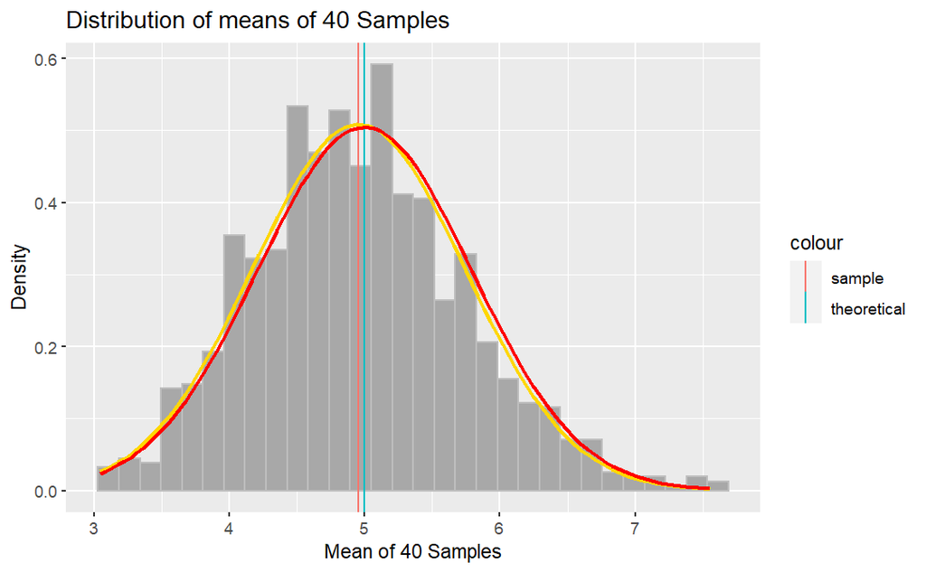

```r
library("ggplot2")
plotdata <- data.frame(means_exponentials)
m <- ggplot(plotdata, aes(x =means_exponentials))
m <- m + geom_histogram(aes(y=..density..), colour="grey",
fill = "grey66")
m <- m + labs(title = "Distribution of means of 40 Samples", x = "Mean of 40 Samples", y =
"Density")
m <- m + geom_vline(aes(xintercept = sample_mean, colour = "sample"))
m <- m + geom_vline(aes(xintercept = theoretical_mean, colour = "theoretical"))
m <- m + stat_function(fun = dnorm, args = list(mean = sample_mean, sd = sample_sd), color =
"gold1", size = 1.0)
m <- m + stat_function(fun = dnorm, args = list(mean = theoretical_mean, sd = theoretical_sd), colour =
"red", size = 1.0)
m
```

These distributions are approximately normal. We see that there is a single hump, centered at the mean and not skewed to either side. The red and blue lines represent the sample and theoretical means, and they are very close. The red line shows the curve created by the theoretical mean and standard deviation, and the gold line shows the curve created by the sample mean and standard deviation. As with the means, they are very close, almost overlapping.

We also see that the values tail off to either side, falling as they approach the extremity. There is a longer tail on the right hand side of the graph that is not the same on the left side.

##Basic inferential data analysis For this analysis, we will use the tooth growth data set that is packaged with R. There are 4 objectives:

1. Load the ToothGrowth data and perform some basic exploratory data analyses
2. Provide a basic summary of the data.
3. Use confidence intervals and/or hypothesis tests to compare tooth growth by supp and dose. (Only use the techniques from class, even if there are other approaches worth considering)
4. State conclusions and the assumptions needed for those conclusions

###Question 1 Load the ToothGrowth data and any needed libraries

```r
library(dplyr)
library(datasets)
library(ggplot2)
data <- ToothGrowth
```

###Question 2 Provide a basic summary of the data

```r
summary(data)
```

```
      len        supp         dose
 Min.   : 4.20   OJ:30   Min.   :0.500
 1st Qu.:13.07   VC:30   1st Qu.:0.500
 Median :19.25           Median :1.000
 Mean   :18.81           Mean   :1.167
 3rd Qu.:25.27           3rd Qu.:2.000
 Max.   :33.90           Max.   :2.000
```

```r
head(data)
```

|  | len | supp | dose |
| --- | --- | --- | --- |
| 1 | 4.2 | VC | 0.5 |
| 2 | 11.5 | VC | 0.5 |
| 3 | 7.3 | VC | 0.5 |
| 4 | 5.8 | VC | 0.5 |
| 5 | 6.4 | VC | 0.5 |
| 6 | 10.0 | VC | 0.5 |

```r
dim(data)
```

```
[1] 60  3
```

```r
length(data)
```

```
[1] 3
```

We now want to do some basic computations to get a sense of the data

```r
grouped_data <- data %>%
  group_by(supp, dose) %>%
  summarize(avg_growth = mean(len),
            sd_growth = sd(len))
grouped_data
```

| supp | dose | avg_growth | sd_growth |
| --- | --- | --- | --- |
| OJ | 0.5 | 13.23 | 4.459709 |
| OJ | 1.0 | 22.70 | 3.910953 |
| OJ | 2.0 | 26.06 | 2.655058 |
| VC | 0.5 | 7.98 | 2.746634 |
| VC | 1.0 | 16.77 | 2.515309 |
| VC | 2.0 | 26.14 | 4.797731 |

We can explore this further with a plot

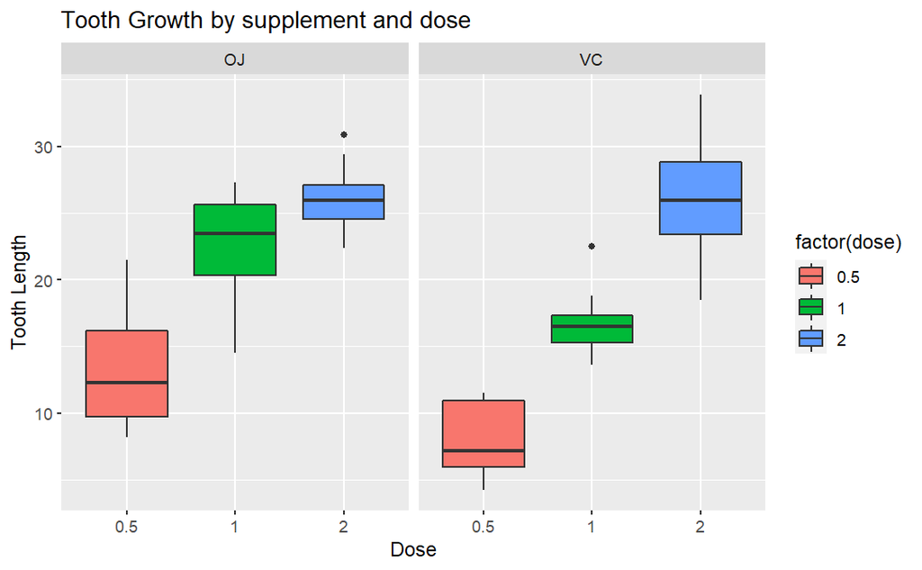

```r
ggplot(data, aes(x=factor(dose), y=len, fill=factor(dose))) +
  geom_boxplot() +
  facet_grid(.~supp) +
  labs(title="Tooth Growth by supplement and dose", x="Dose", y="Tooth Length")
```

###Use confidence intervals and/or hypothesis tests to compare tooth growth by supp and dose

From the plots above, it appears that OJ with doses .5 and 1 both promote more growth than VC at the same dosage. We can run a t-test on each dose level to see if there is a significant difference. The null hypothesis is that there is no difference in tooth growth at a given dose level between OJ and VC supplements. We can see that the interquartile ranges appear to be different from the graph, so we will not assum that the variances are equal.

```r
oj5 <- data %>% filter(supp=="OJ", dose=="0.5")
oj1 <- data %>% filter(supp=="OJ", dose=="1")
vc5 <- data %>% filter(supp=="VC", dose=="0.5")
vc1 <- data %>% filter(supp=="VC", dose=="1")
t.test(oj5$len, vc5$len, var.equal = FALSE)
```

```
    Welch Two Sample t-test

data:  oj5$len and vc5$len
t = 3.1697, df = 14.969, p-value = 0.006359
alternative hypothesis: true difference in means is not equal to 0
95 percent confidence interval:
 1.719057 8.780943
sample estimates:
mean of x mean of y
    13.23      7.98
```

```r
t.test(oj1$len, vc1$len, var.equal = FALSE)
```

```
    Welch Two Sample t-test

data:  oj1$len and vc1$len
t = 4.0328, df = 15.358, p-value = 0.001038
alternative hypothesis: true difference in means is not equal to 0
95 percent confidence interval:
 2.802148 9.057852
sample estimates:
mean of x mean of y
    22.70     16.77
```

The graph is less indicative about dose 2. Those boxplots appear to be fairly close and the interquartile ranges overlap. We will run a separate t test on dose 2 across the supplements. Again, the null hypothesis is that there is no difference in length.

```r
oj2 <- data %>% filter(supp=="OJ", dose=="2")
vc2 <- data %>% filter(supp=="VC", dose=="2")
t.test(oj2$len, vc2$len, var.equal = FALSE)
```

```
    Welch Two Sample t-test

data:  oj2$len and vc2$len
t = -0.046136, df = 14.04, p-value = 0.9639
alternative hypothesis: true difference in means is not equal to 0
95 percent confidence interval:
 -3.79807  3.63807
sample estimates:
mean of x mean of y
    26.06     26.14
```

###State conclusions and the assumptions needed for those conclusions

Now to interpret the hypothesis tests. In both the .5 and the 1 dose test does the 95% confidence interval does not overlap 0. That is, both the upper and lower values of the confidence interval are above 0. Therefore, we reject the null hypothesis of no difference and find support for the alternative hypothesis that the difference in means is not 0.

In the test where the dose is 2, the 95% confidence interval does overlap 0. That is, the lower bound is less than 0, whereas the upper bound is greater than 0. Therefore, we fail to reject the null hypothesis for the dose level of 2.

Based off of these test results, we can conclude that: * There is a significant difference in tooth growth when OJ is used vs VC for dose levels 0.5 and 1 * There is no significant difference in tooth growth when OJ is used vs VC for dose levels of 2

One assumption is that the sample size is adequate. Since this comes from an experiment, we assume that the researchers had an adequate sample. We have 60 total observations, but know nothing of the overall population of guinea pigs.

We also assume that the measurements are not paired and do not assume that the variances are equal. We also assume that the samples are independent and that there was no crossover between the guinea pigs who received OJ and VC. In other words, no subject received both OJ and VC.